# Assignment 06 - Solutions

## Q2: A/B test power and subgroup analysis

**a.** Load the required data frame and produce the boxplots.

```r
#' Required variables: df.ab1 (data.frame)
#' Required plots: boxplots
df.ab1 <- read.csv("session_ab_test.csv")
head(df.ab1)
```

```
##   user_id     group age_band    sex session_duration_min
## 1   U0132   control    25-34 Female                6.235
## 2   U0204   control    45-54 Female               12.826
## 3   U0051   control      55+   Male                3.155
## 4   U0586 treatment    25-34 Female               14.651
## 5   U0139   control    25-34 Female                7.395
## 6   U0633 treatment    35-44   Male                1.321
```

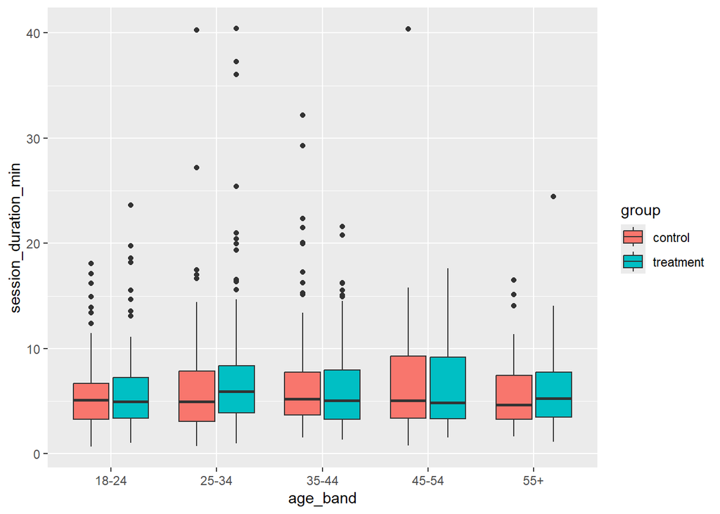

```r
ggplot(df.ab1, aes(age_band, session_duration_min, fill = group)) +
  geom_boxplot()
```

**b.** Add the new variable with the log-durations.

```r
#' Required variables: df.ab1.log (data.frame)
#' Required plots: boxplots or violin plots
df.ab1.log <- mutate(df.ab1, duration.log = log(session_duration_min))
head(df.ab1.log)
```

```
##   user_id     group age_band    sex session_duration_min duration.log
## 1   U0132   control    25-34 Female                6.235     1.830179
## 2   U0204   control    45-54 Female               12.826     2.551474
## 3   U0051   control      55+   Male                3.155     1.148988
## 4   U0586 treatment    25-34 Female               14.651     2.684509
## 5   U0139   control    25-34 Female                7.395     2.000804
## 6   U0633 treatment    35-44   Male                1.321     0.278389
```

```r
dim(df.ab1.log)
```

```
## [1] 1000    6
```

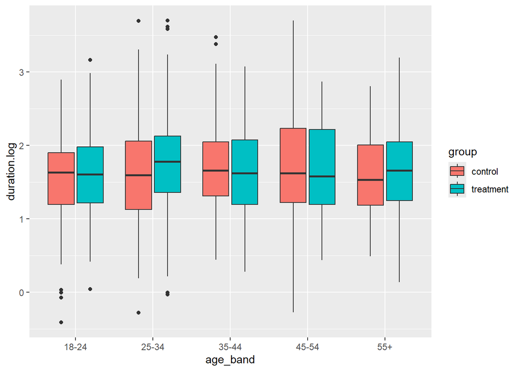

```r
ggplot(df.ab1.log, aes(age_band, duration.log, fill = group)) +
  geom_boxplot()
```

**c.** Calculate the required sample size to get a set of tests with the desired statistical properties.

```r
#' Required variables: required_n_per_group (numeric)
#' Required plots: NA
h1 <- "one.sided"
alpha <- 0.05 / 5
delta <- 0.08
pi.star <- 0.8
sd.ref <- 0.3
power <- 0.8
tmp <- power.t.test(
  delta = delta,
  sig.level = alpha,
  sd = sd.ref,
  power = power,
  type = "two.sample",
  alternative = h1
  )
required_n_per_group <- ceiling(tmp$n)
required_n_per_group
```

```
## [1] 284
```

**d.** Produce the required summary data frame with the available sample sizes.

```r
#' Required variables: NA
#' Required plots: NA

table(df.ab1$group, df.ab1$age_band)
```

```
##
##             18-24 25-34 35-44 45-54 55+
##   control     103   138   128    76  55
##   treatment   101   161   126    67  45
```

```r
# Each grouped band is less than required_n_per_group, therefore available sample is not large enough
```

**e.** Create the modified dataframe `df.ab1.log2`.

```r
#' Required variables: df.ab1.log2 (data.frame)
#' Required plots: NA
df.ab1.log2 <- df.ab1.log %>%
  mutate(new_age_band = ifelse(age_band %in% c("18-24", "25-43"),
                               "younger",
                               "older"))
table(df.ab1.log2$group, df.ab1.log2$new_age_band)
```

```
##
##             older younger
##   control     397     103
##   treatment   399     101
```

**f.** Perform the hypotheses tests and calculate the corrected p-values.

```r
#' Required variables: pvals.raw (numeric); pvals.holm (numeric)
#' Required plots: NA

younger_df <- subset(df.ab1.log2, new_age_band =="younger")
older_df <- subset(df.ab1.log2, new_age_band == "older")

t1 <- t.test(duration.log ~ group, data = younger_df,
             alternative = "greater", conf.level = 0.95)
t2 <- t.test(duration.log ~ group, data = older_df,
             alternative = "greater", conf.level = 0.95)
pvals.raw <- c(t1$p.value, t2$p.value)
pvals.holm <- p.adjust(pvals.raw, method = "holm")
pvals.raw
```

```
## [1] 0.6762871 0.8879046
```

```r
pvals.holm
```

```
## [1] 1 1
```

```r
# The differences are not statistically significant
```

## Q3: paired t test

**a.** Load and prepare the data.

```r
#' Required variables: df.paired.t (data.frame)
#' Required plots: NA

df.paired <- readRDS("UPMSP_SA_full_results.rds")
df.paired.t <- df.paired %>%
  select(Algorithm, Instance, Makespan) %>%
  filter(Algorithm %in% c("Full", "no-2SH")) %>%
  group_by(Algorithm, Instance) %>%
  summarise(MeanMS = mean(Makespan, na.rm = TRUE), .groups = "drop") %>%
  arrange(Algorithm, Instance)
dim(df.paired.t)
```

```
## [1] 114   3
```

**b.** Formalise the test hypotheses

Defining $d_j = y_{(no2sh), j} - y_{(full), j}$, the hypotheses can be written as:
$$\begin{cases}
H_0: \mu_D = 0\\
H_A: \mu_D > 0
\end{cases}$$

**c.** Perform the paired t-test.

```r
#' Required variables: pval.paired (numeric); diff.paired (numeric); ci.paired (numeric)
#' Required plots: NA

df.wide <- df.paired.t %>%
  pivot_wider(names_from = Algorithm, values_from = MeanMS)
dim(df.wide)
```

```
## [1] 57  3
```

```r
names(df.wide)
```

```
## [1] "Instance" "Full"     "no-2SH"
```

```r
diffs <- df.wide$`no-2SH` - df.wide$Full

t.paired <- t.test(
  x = df.wide$`no-2SH`,
  y = df.wide$Full,
  paired = TRUE,
  alternative = "greater",
  conf.level = 0.95
)
t.paired
```

```
##
##  Paired t-test
##
## data:  df.wide$`no-2SH` and df.wide$Full
## t = 4.6942, df = 56, p-value = 8.854e-06
## alternative hypothesis: true mean difference is greater than 0
## 95 percent confidence interval:
##  4.37335     Inf
## sample estimates:
## mean difference
##         6.79401
```

```r
pval.paired <- t.paired$p.value
diff.paired <- as.numeric(t.paired$estimate)
ci.paired <- t.paired$conf.int
effect_size <- diff.paired/ sd(diffs)
effect_size
```

```
## [1] 0.6217658
```

```r
# Results are statistically significant at the 95% confidence level
```

**d.** Ignore the pairing and run a simple t-test to see what comes out.

```r
#' Required variables: NA
#' Required plots: NA
t.unpaired <- t.test(
  x = df.wide$`no-2SH`,
  y = df.wide$Full,
  paired = FALSE,
  alternative = "greater",
  conf.level = 0.95
)
t.unpaired
```

```
##
##  Welch Two Sample t-test
##
## data:  df.wide$`no-2SH` and df.wide$Full
## t = 0.2345, df = 111.94, p-value = 0.4075
## alternative hypothesis: true difference in means is greater than 0
## 95 percent confidence interval:
##  -41.25791       Inf
## sample estimates:
## mean of x mean of y
##  203.4343  196.6403
```

```r
pval.unpaired <- t.unpaired$p.value

# This test was not able to detect the difference
```

## Q4: ANOVA

**a.** Load the dataset and generate the data summary as instructed.

```r
#' Required variables: df.strat (data.frame); df.strat.stats (data.frame)
#' Required plots: NA
df.strat <- read.csv("business_strategies.csv")
str(df.strat)
```

```
## 'data.frame':    480 obs. of  2 variables:
##  $ strategy     : chr  "Strategy_A" "Strategy_A" "Strategy_A" "Strategy_A" ...
##  $ Revenue30Days: num  30.8 42.9 40.1 48.5 40.4 ...
```

```r
dim(df.strat)
```

```
## [1] 480   2
```

```r
df.strat.stats <- df.strat %>%
  group_by(strategy) %>%
  summarise(
    meanRev = mean(Revenue30Days, na.rm = TRUE),
    sdRev = sd(Revenue30Days, na.rm = TRUE),
    N = n(),
    .groups = "drop"
  )
df.strat.stats
```

```
## # A tibble: 6 × 4
##   strategy   meanRev sdRev     N
##   <chr>        <dbl> <dbl> <int>
## 1 Strategy_A    48.1  8.50    80
## 2 Strategy_B    49.7  8.51    80
## 3 Strategy_C    54.4  9.00    80
## 4 Strategy_D    56.2  8.02    80
## 5 Strategy_E    59.1  8.76    80
## 6 Strategy_F    61.1  9.69    80
```

**b.** Generate the faceted normal QQ-plots

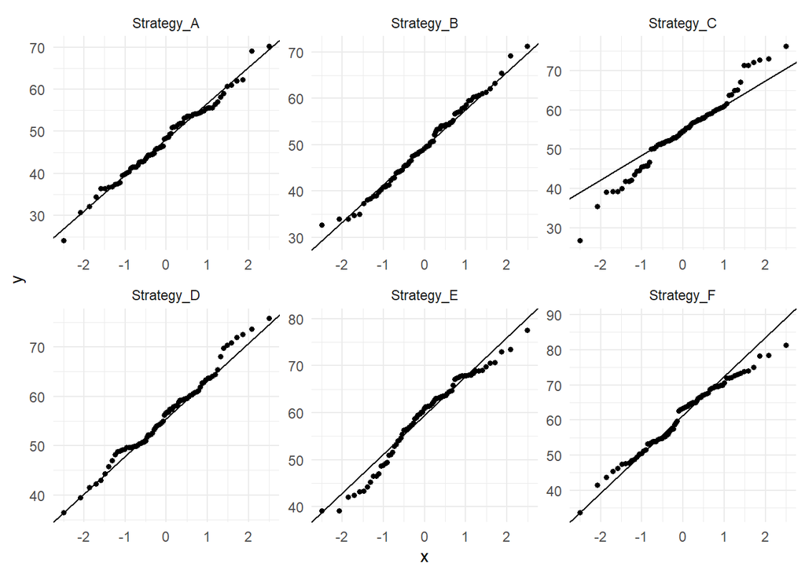

```r
#' Required variables: NA
#' Required plots: faceted qqplots

ggplot(df.strat, aes(sample = Revenue30Days)) +
  geom_qq(size = 1.2) +
  geom_qq_line() +
  facet_wrap(~ strategy, scales = "free") +
  theme_minimal()
```

**c.** Perform the Fligner-Kileen test

```r
#' Required variables: NA
#' Required plots: NA
fligner_res <- fligner.test(Revenue30Days ~ strategy, data = df.strat)
fligner_res
```

```
##
##  Fligner-Killeen test of homogeneity of variances
##
## data:  Revenue30Days by strategy
## Fligner-Killeen:med chi-squared = 4.7401, df = 5, p-value = 0.4484
```

```r
# p > 0.05 so we fail to reject the null hypothesis
```

**d.** Perform the ANOVA

```r
#' Required variables: aov.strat (aov)
#' Required plots: NA
aov.strat <- aov(Revenue30Days ~ strategy, data = df.strat)
summary(aov.strat)
```

```
##              Df Sum Sq Mean Sq F value Pr(>F)
## strategy      5  10539  2107.8   27.46 <2e-16 ***
## Residuals   474  36383    76.8
## ---
## Signif. codes:  0 '***' 0.001 '**' 0.01 '*' 0.05 '.' 0.1 ' ' 1
```

```r
# Since p < 0.01 we reject the null hypothesis at the 99% confidence level
```

```r
#' Required variables: df.strat (data.frame); aov.strat (aov); strat.tukey (glht)
#' Required plots: NA
df.strat$strategy <- as.factor(df.strat$strategy)
library(multcomp)
aov.strat <- aov(Revenue30Days ~ strategy, data = df.strat)
summary(aov.strat)
```

```
##              Df Sum Sq Mean Sq F value Pr(>F)
## strategy      5  10539  2107.8   27.46 <2e-16 ***
## Residuals   474  36383    76.8
## ---
## Signif. codes:  0 '***' 0.001 '**' 0.01 '*' 0.05 '.' 0.1 ' ' 1
```

```r
strat.tukey <- glht(aov.strat, linfct = mcp(strategy = "Tukey"))
print(strat.tukey)
```

```
##
##   General Linear Hypotheses
##
## Multiple Comparisons of Means: Tukey Contrasts
##
##
## Linear Hypotheses:
##                              Estimate
## Strategy_B - Strategy_A == 0    1.593
## Strategy_C - Strategy_A == 0    6.293
## Strategy_D - Strategy_A == 0    8.102
## Strategy_E - Strategy_A == 0   11.030
## Strategy_F - Strategy_A == 0   13.016
## Strategy_C - Strategy_B == 0    4.700
## Strategy_D - Strategy_B == 0    6.509
## Strategy_E - Strategy_B == 0    9.437
## Strategy_F - Strategy_B == 0   11.423
## Strategy_D - Strategy_C == 0    1.809
## Strategy_E - Strategy_C == 0    4.737
## Strategy_F - Strategy_C == 0    6.723
## Strategy_E - Strategy_D == 0    2.928
## Strategy_F - Strategy_D == 0    4.914
## Strategy_F - Strategy_E == 0    1.986
```

## Q5: Blocked ANOVA

**a.** Load and prepare the data.

```r
#' Required variables: df.cbd (data.frame)
#' Required plots: NA
df.full <- readRDS("UPMSP_SA_full_results.rds")
df.cbd <- df.full %>%
  group_by(Algorithm, Instance) %>%
  summarise(
    MeanMS = mean(Makespan, na.rm = TRUE),
    .groups = "drop"
  )
df.cbd$Algorithm <- as.factor(df.cbd$Algorithm)
df.cbd$Instance <- as.factor(df.cbd$Instance)

df.cbd$Algorithm <- relevel(df.cbd$Algorithm, ref = "Full")
head(df.cbd)
```

```
## # A tibble: 6 × 3
##   Algorithm Instance           MeanMS
##   <fct>     <fct>               <dbl>
## 1 Full      I_100_25_S_1-124_1  112.
## 2 Full      I_250_10_S_1-9_1    308.
## 3 Full      I_50_15_S_1-124_2   110.
## 4 Full      I_150_25_S_1-9_1     48.7
## 5 Full      I_100_20_S_1-124_1  149.
## 6 Full      I_200_30_S_1-99_1   141.
```

**b.** Perform a blocked ANOVA test

```r
#' Required variables: NA
#' Required plots: NA
aov.cbd <- aov(MeanMS ~ Algorithm + Instance, data = df.cbd)
summary(aov.cbd)
```

```
##               Df   Sum Sq Mean Sq F value Pr(>F)
## Algorithm     21  1665966   79332   203.6 <2e-16 ***
## Instance      56 32941866  588248  1509.4 <2e-16 ***
## Residuals   1176   458307     390
## ---
## Signif. codes:  0 '***' 0.001 '**' 0.01 '*' 0.05 '.' 0.1 ' ' 1
```

**c.** Perform the Dunnett test to check which methods are significantly different from the reference one.

```r
#' Required variables: cbd.mht
#' Required plots: NA
cbd.mht <- glht(aov.cbd, linfct = mcp(Algorithm = "Dunnett"))
summary(cbd.mht)
```

```
## Warning in RET$pfunction("adjusted", ...): Completion with error > abseps
## Warning in RET$pfunction("adjusted", ...): Completion with error > abseps
## Warning in RET$pfunction("adjusted", ...): Completion with error > abseps
##
##   Simultaneous Tests for General Linear Hypotheses
##
## Multiple Comparisons of Means: Dunnett Contrasts
##
##
## Fit: aov(formula = MeanMS ~ Algorithm + Instance, data = df.cbd)
##
## Linear Hypotheses:
##                            Estimate Std. Error t value Pr(>|t|)
## no-2SH - Full == 0          6.79401    3.69787   1.837   0.5218
## no-DSW - Full == 0          5.20118    3.69787   1.407   0.8517
## no-DSW.no-2SH - Full == 0  10.05353    3.69787   2.719   0.0857 .
## no-DSW.no-SWP - Full == 0  16.96059    3.69787   4.587   <0.001 ***
## no-DSW.no-SWT - Full == 0   5.75383    3.69787   1.556   0.7456
## no-DSW.no-TSK - Full == 0  83.94970    3.69787  22.702   <0.001 ***
## no-SHF - Full == 0         -0.00515    3.69787  -0.001   1.0000
## no-SHF.no-2SH - Full == 0   8.33095    3.69787   2.253   0.2511
## no-SHF.no-DSW - Full == 0   4.91787    3.69787   1.330   0.8963
## no-SHF.no-SWP - Full == 0   0.42749    3.69787   0.116   1.0000
## no-SHF.no-SWT - Full == 0   0.67401    3.69787   0.182   1.0000
## no-SHF.no-TSK - Full == 0  71.58276    3.69787  19.358   <0.001 ***
## no-SWP - Full == 0          0.88406    3.69787   0.239   1.0000
## no-SWP.no-2SH - Full == 0   3.77531    3.69787   1.021   0.9897
## no-SWP.no-SWT - Full == 0   0.51934    3.69787   0.140   1.0000
## no-SWP.no-TSK - Full == 0 121.80593    3.69787  32.939   <0.001 ***
## no-SWT - Full == 0         -0.58197    3.69787  -0.157   1.0000
## no-SWT.no-2SH - Full == 0   5.93013    3.69787   1.604   0.7081
## no-SWT.no-TSK - Full == 0  70.43936    3.69787  19.049   <0.001 ***
## no-TSK - Full == 0         73.88049    3.69787  19.979   <0.001 ***
## no-TSK.no-2SH - Full == 0  76.11231    3.69787  20.583   <0.001 ***
## ---
## Signif. codes:  0 '***' 0.001 '**' 0.01 '*' 0.05 '.' 0.1 ' ' 1
## (Adjusted p values reported -- single-step method)
```

**d.** Generate the visualisation of the differences.

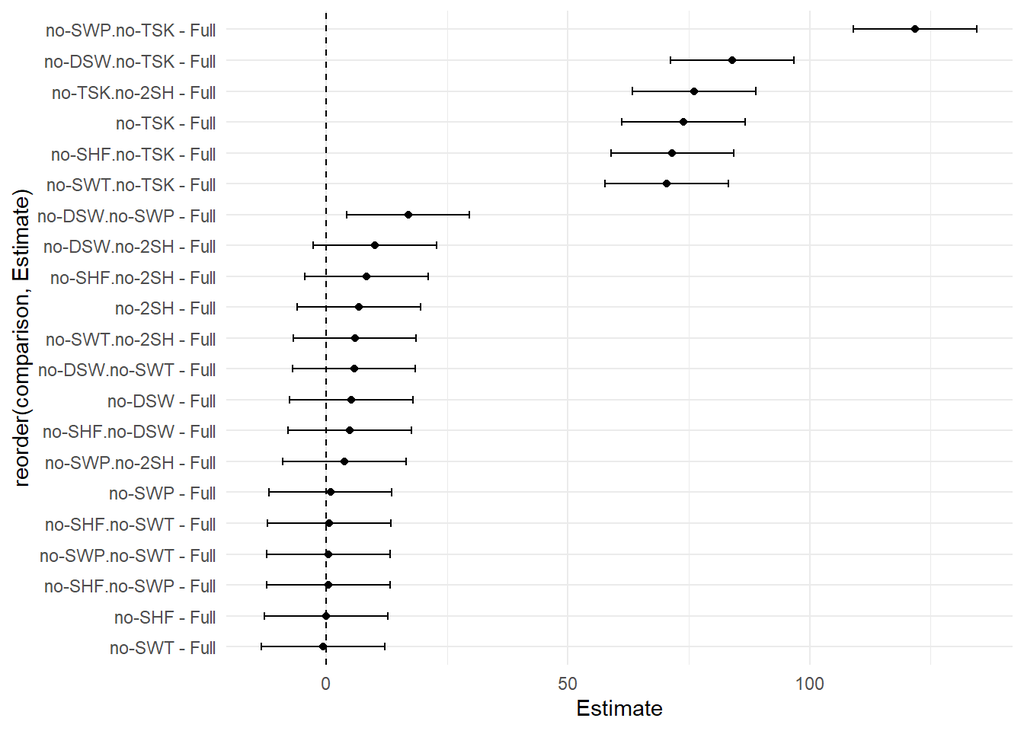

```r
#' Required variables: NA
#' Required plots: confidence intervals
ci_mat <- as.data.frame(confint(cbd.mht, level = 0.99)$confint)
ci_mat$comparison <- rownames(ci_mat)
rownames(ci_mat) <- NULL
names(ci_mat)[1:3] <- c("Estimate", "lwr", "upr")

ggplot(ci_mat %>% arrange(Estimate), aes(x = reorder(comparison, Estimate), y = Estimate)) +
  geom_point() +
  geom_errorbar(aes(ymin = lwr, ymax = upr), width = 0.25) +
  coord_flip() +
  geom_hline(yintercept = 0, linetype = "dashed") +
  theme_minimal()
```

```r
better_than_full <- ci_mat %>% filter(upr < 0) %>% pull(comparison)
better_than_full
## character(0)
not_sig_worse <- ci_mat %>% filter(!(lwr > 0)) %>% pull(comparison)
not_sig_worse
```

```
##  [1] "no-2SH - Full"        "no-DSW - Full"        "no-DSW.no-2SH - Full"
##  [4] "no-DSW.no-SWT - Full" "no-SHF - Full"        "no-SHF.no-2SH - Full"
##  [7] "no-SHF.no-DSW - Full" "no-SHF.no-SWP - Full" "no-SHF.no-SWT - Full"
## [10] "no-SWP - Full"        "no-SWP.no-2SH - Full" "no-SWP.no-SWT - Full"
## [13] "no-SWT - Full"        "no-SWT.no-2SH - Full"
```